# Motif figures from MEME output with ggplot2

```r
library(memeplotr)
library(ggplot2)
```

## The problem this package solves

MEME Suite writes its own HTML and EPS: the motif block diagram and the sequence logos come out with fixed colours, fixed block shapes, no way to reorder the sequences, and no way to put the diagram next to a phylogeny. Once a reviewer asks for a colour-blind-safe palette, a clade-ordered figure, or a panel letter, the output has to be redrawn by hand.

`memeplotr` reads the XML instead and hands back tidy data frames and ordinary `ggplot2` objects. Everything after that is the grammar you already know: `+ scale_fill_*()`, `+ theme_*()`, `+ labs()`, `patchwork`, `ggsave()`.

## Reading a MEME run

`read_meme()` takes `meme.xml`, `streme.xml` or `dreme.xml` and returns a `meme_result`: a list of tidy tables plus the position weight matrices.

```r
xml <- system.file("extdata", "example_meme.xml", package = "memeplotr")
res <- read_meme(xml)
res
```

```
#> <meme_result>  MEME 5.5.5   alphabet: protein
#>   motifs     : 6  (widths 12-29)
#>   sequences  : 12
#>   sites      : 46 (scanned)
#>
#>   motif                consensus width nsites evalue
#>  MEME-1 WTPEEDELLRRLVEKHGARNW...    29     12  1e-62
#>  MEME-2    GKSCRLRWLNYLRPDLKRGNI    21     11  1e-55
#>  MEME-3          SEEEDRIIRLHSLLG    15      8  1e-48
#>  MEME-4       NYWNTHLKKRLLSQGIDP    18      4  1e-41
#>  MEME-5 MSDLLQAPHCFSPTTEEAWMA...    25      5  1e-34
#>  MEME-6             KQLERSSILSSY    12      4  1e-27
```

The pieces are plain data frames, so they work with `dplyr`, `tidyr` and everything else:

```r
head(res$motifs[, c("motif", "width", "nsites", "evalue", "consensus")])
```

```
#> # A tibble: 6 x 5
#>   motif  width nsites evalue consensus
#>   <chr>  <int>  <int>  <dbl> <chr>
#> 1 MEME-1    29     12  1e-62 WTPEEDELLRRLVEKHGARNWSLIARSIP
#> 2 MEME-2    21     11  1e-55 GKSCRLRWLNYLRPDLKRGNI
#> 3 MEME-3    15      8  1e-48 SEEEDRIIRLHSLLG
#> 4 MEME-4    18      4  1e-41 NYWNTHLKKRLLSQGIDP
#> 5 MEME-5    25      5  1e-34 MSDLLQAPHCFSPTTEEAWMADFLN
#> 6 MEME-6    12      4  1e-27 KQLERSSILSSY
```

```r
head(res$sites, 4)
```

```
#> # A tibble: 4 x 10
#>   sequence_id sequence motif_id motif  start  stop width strand   pvalue source
#>   <chr>       <chr>    <chr>    <chr>  <int> <int> <int> <chr>     <dbl> <chr>
#> 1 sequence_0  Ath_MYB1 motif_1  MEME-1    29    57    29 *      1.64e-23 scanned
#> 2 sequence_0  Ath_MYB1 motif_2  MEME-2    64    84    21 *      4.16e-18 scanned
#> 3 sequence_0  Ath_MYB1 motif_3  MEME-3   136   150    15 *      2.95e-11 scanned
#> 4 sequence_0  Ath_MYB1 motif_4  MEME-4   181   198    18 *      2.86e-25 scanned
```

```r
head(res$sequences, 4)
```

```
#> # A tibble: 4 x 6
#>   sequence_id sequence length weight seq_pvalue n_sites
#>   <chr>       <chr>     <int>  <dbl>      <dbl>   <int>
#> 1 sequence_0  Ath_MYB1    312      1   5.89e-84       4
#> 2 sequence_1  Ath_MYB2    298      1   2.67e-78       3
#> 3 sequence_2  Osa_MYB1    341      1   8.02e-73       4
#> 4 sequence_3  Osa_MYB2    327      1   2.01e-51       3
```

`summary()` gives one row per motif, and `as.data.frame()` flattens the sites table with the motif metadata joined on.

```r
summary(res)
```

```
#> # A tibble: 6 x 9
#>   motif  consensus  width evalue n_sites n_seqs pct_seqs min_pvalue median_start
#>   <chr>  <chr>      <int>  <dbl>   <int>  <int>    <dbl>      <dbl>        <dbl>
#> 1 MEME-1 WTPEEDELL~    29  1e-62      13     12    100     7.92e-28          33
#> 2 MEME-2 GKSCRLRWL~    21  1e-55      11     11     91.7   8.66e-27          69
#> 3 MEME-3 SEEEDRIIR~    15  1e-48       8      8     66.7   3.19e-21         136.
#> 4 MEME-4 NYWNTHLKK~    18  1e-41       4      4     33.3   4.97e-26         194.
#> 5 MEME-5 MSDLLQAPH~    25  1e-34       5      5     41.7   1.56e-26          13
#> 6 MEME-6 KQLERSSIL~    12  1e-27       5      4     33.3   7.78e-27         306
```

Motif names from MEME (`MEME-1`, `MEME-2`, …) are rarely what you want on a figure. `relabel_motifs()` renames them everywhere at once - across the motif table, the site tables and the PWM list:

```r
res_lab <- relabel_motifs(res, c("R2R3-a", "R2R3-b", "SANT", "LHEQLE",
                                 "C-term", "Gly-rich"))
head(res_lab$motifs$motif)
```

```
#> [1] "R2R3-a"   "R2R3-b"   "SANT"     "LHEQLE"   "C-term"   "Gly-rich"
```

## Motif composition diagrams

`gg_motif_map()` is the block diagram. The default is an arrow pointing in the direction of the match:

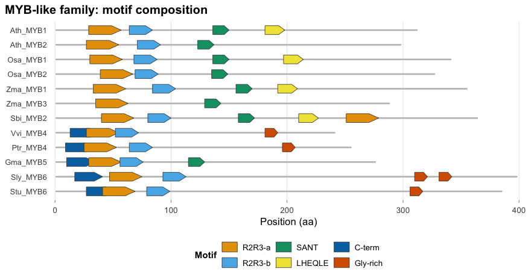

```r
gg_motif_map(res_lab, title = "MYB-like family: motif composition")
```

Block shape, palette, height and opacity are arguments; `motif_shapes()` lists the shapes and `memeplotr_palettes()` the built-in palettes.

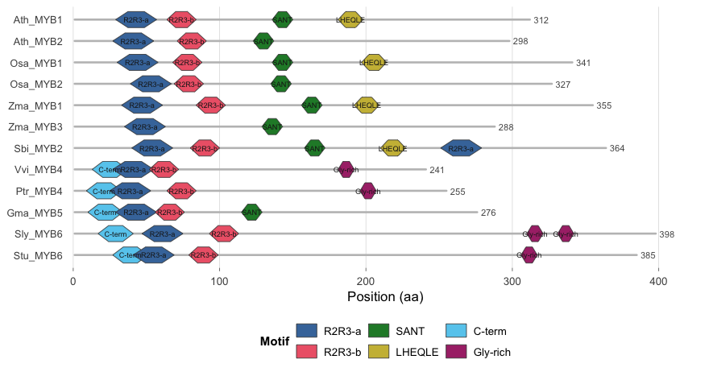

```r
gg_motif_map(res_lab, shape = "hexagon", palette = "bright", height = 0.75,
             label = TRUE, label_size = 2.1, length_label = TRUE)
```

Sequences can be ordered by input order, name, length, motif count, an explicit vector, or a phylogeny. Sites can be filtered by motif, by sequence, and by p-value.

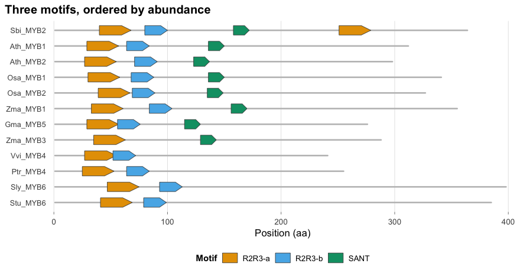

```r
gg_motif_map(res_lab, order = "count", motifs = c("R2R3-a", "R2R3-b", "SANT"),
             pvalue_max = 1e-8, title = "Three motifs, ordered by abundance")
```

Any single motif can be pinned to a colour while the rest come from the palette - useful when one motif is the point of the figure:

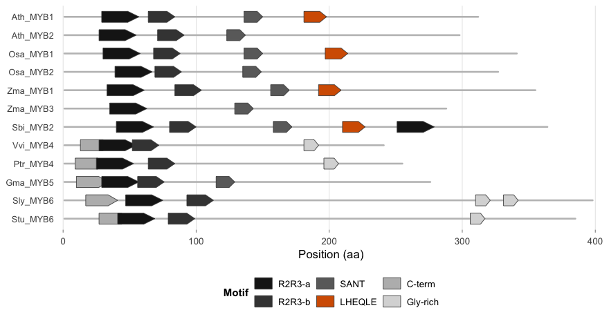

```r
gg_motif_map(res_lab, colours = c("LHEQLE" = "#D55E00"), palette = "grey")
```

## Aligning the diagram to a phylogeny

This is the part MEME cannot do. `gg_tree_motifs()` draws a Newick tree in pure `ggplot2` and puts the motif map beside it on exactly the same rows.

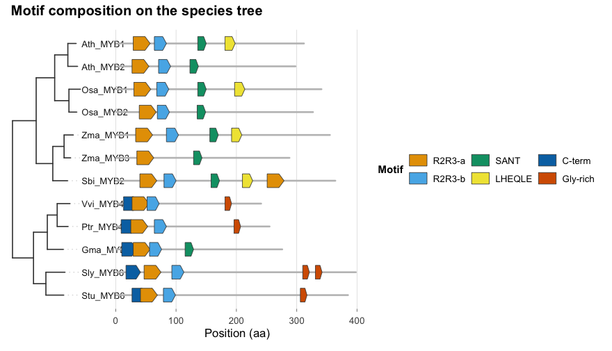

```r
nwk <- system.file("extdata", "example_tree.nwk", package = "memeplotr")
gg_tree_motifs(res_lab, nwk, align_tips = TRUE, widths = c(1, 2.6),
               title = "Motif composition on the species tree")
```

Tips that are in the tree but have no motif hits keep their row, so nothing silently shifts out of register. The tree panel is an ordinary plot too:

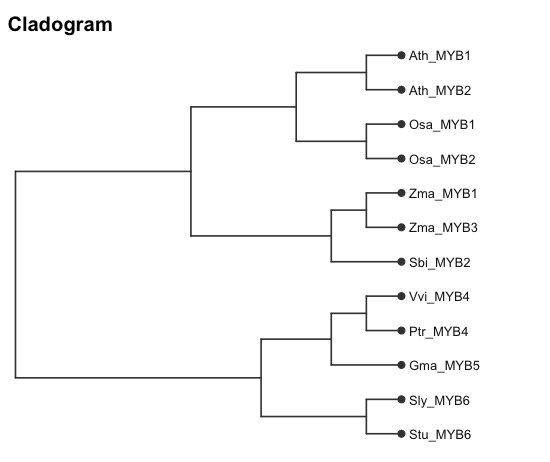

```r
gg_phylo(nwk, cladogram = TRUE, tip_points = TRUE, node_labels = TRUE,
         title = "Cladogram")
```

To align a plot of your own, ask for the tip order and build your plot on it, then compose with `gg_tree_panel()`:

```r
tree_tip_order(nwk)
```

```
#>  [1] "Ath_MYB1" "Ath_MYB2" "Osa_MYB1" "Osa_MYB2" "Zma_MYB1" "Zma_MYB3"
#>  [7] "Sbi_MYB2" "Vvi_MYB4" "Ptr_MYB4" "Gma_MYB5" "Sly_MYB6" "Stu_MYB6"
```

## Sequence logos

Logos are built from the PWMs as polygons - no font or graphics-device dependency, so the letters respond to `fill`, `colour`, `alpha` and themes like any other layer.

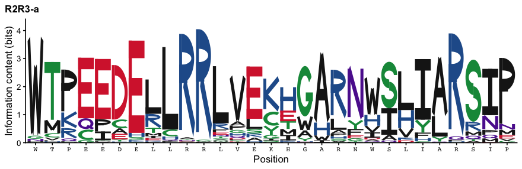

```r
gg_motif_logo(res_lab, "R2R3-a", show_consensus = TRUE)
```

The stack height is information content by default, or probability; the letter colouring follows amino-acid chemistry, hydropathy, the Taylor scheme, a nucleotide scheme, or a flat colour, and individual letters can be overridden.

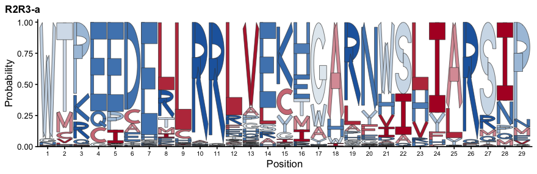

```r
gg_motif_logo(res_lab, "R2R3-a", method = "probability",
              scheme = "hydrophobicity", outline = "grey25")
```

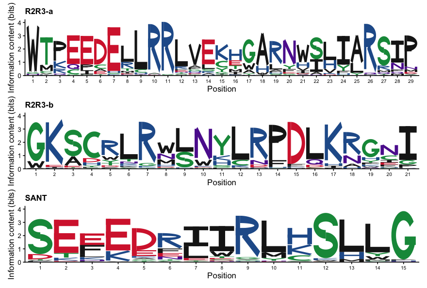

```r
gg_motif_logos(res_lab, motifs = c("R2R3-a", "R2R3-b", "SANT"), ncol = 1)
```

For DNA motifs, `reverse_complement = TRUE` flips the matrix.

## Summary and comparative views

For families too large to read as a block diagram, or when the question is presence/absence rather than position:

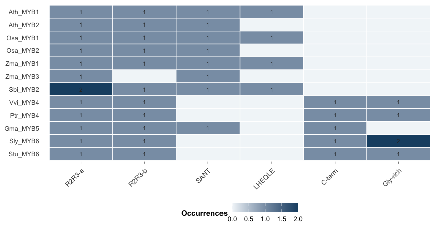

```r
gg_motif_heatmap(res_lab, order = "tree", tree = nwk, keep_empty = TRUE,
                 value = "count", label = TRUE)
```

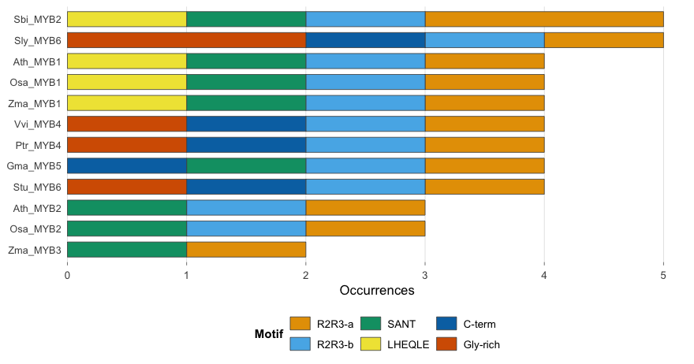

```r
gg_motif_counts(res_lab, order = "count")
```

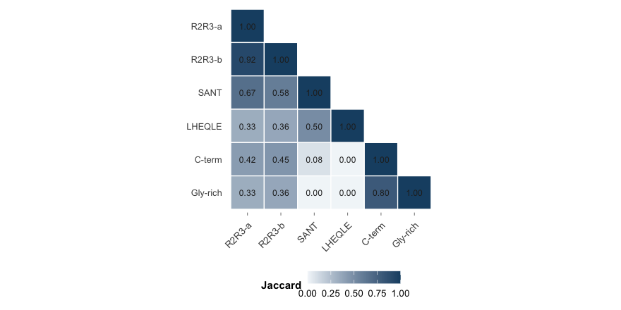

```r
gg_motif_cooccurrence(res_lab, measure = "jaccard", label = TRUE)
```

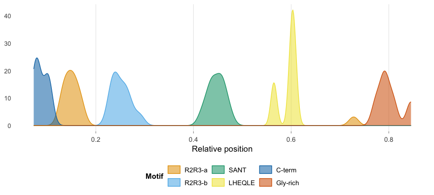

```r
gg_motif_positions(res_lab, scale = "relative")
```

Because the heatmap and the count bars use the same vertical convention as the motif map, they can be composed against the tree as well:

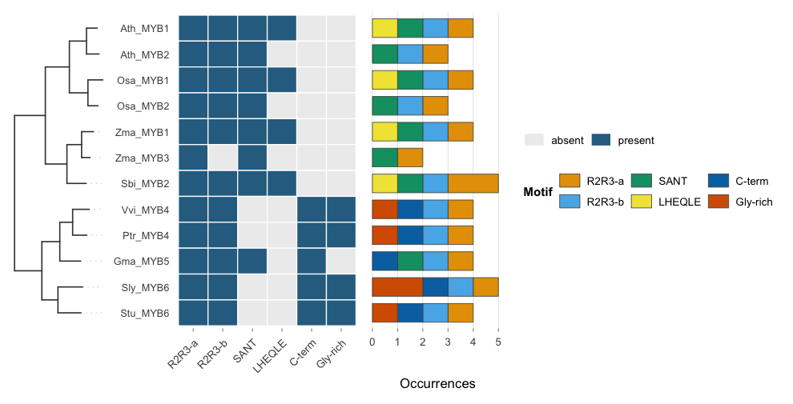

```r
library(patchwork)
gg_tree_panel(
  gg_phylo(nwk, tip_labels = FALSE, align_tips = TRUE),
  list(gg_motif_heatmap(res_lab, order = "tree", tree = nwk, keep_empty = TRUE),
       gg_motif_counts(res_lab, order = "tree", tree = nwk, keep_empty = TRUE,
                       y_labels = FALSE)),
  widths = c(0.7, 1.4, 1))
```

## Output from other tools

Anything that reports “this motif is at these coordinates in this sequence” can be plotted with the same functions. `read_fimo()` reads FIMO’s TSV, and `as_motif_table()` adapts an arbitrary data frame by naming its columns:

```r
fimo <- read_fimo(system.file("extdata", "example_fimo.tsv",
                              package = "memeplotr"))
head(fimo, 3)
```

```
#> # A tibble: 3 x 9
#>   sequence motif  motif_id start  stop width strand   pvalue seq_length
#>   <chr>    <fct>  <chr>    <dbl> <dbl> <dbl> <chr>     <dbl>      <dbl>
#> 1 Ath_MYB1 MEME-1 MEME-1      29    57    29 +      1.64e-23        198
#> 2 Ath_MYB1 MEME-2 MEME-2      64    84    21 +      4.16e-18        198
#> 3 Ath_MYB1 MEME-3 MEME-3     136   150    15 +      2.95e-11        198
```

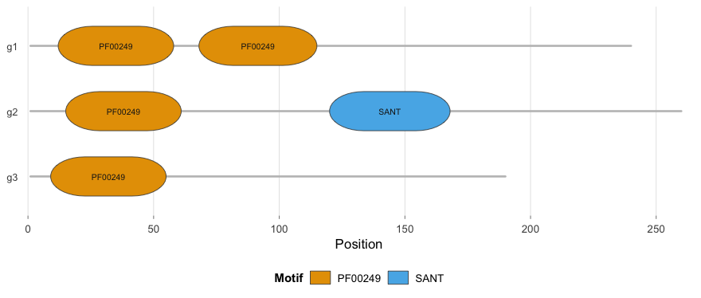

```r
hits <- data.frame(
  gene  = c("g1", "g1", "g2", "g2", "g3"),
  dom   = c("PF00249", "PF00249", "PF00249", "SANT", "PF00249"),
  from  = c(12, 68, 15, 120, 9),
  to    = c(58, 115, 61, 168, 55),
  len   = c(240, 240, 260, 260, 190))
tbl <- as_motif_table(hits, sequence = "gene", motif = "dom",
                      start = "from", stop = "to", seq_length = "len")
gg_motif_map(tbl, shape = "capsule", label = TRUE)
```

## It is still a ggplot

Nothing is locked down. Replace the scale, change the theme, add layers, facet, annotate:

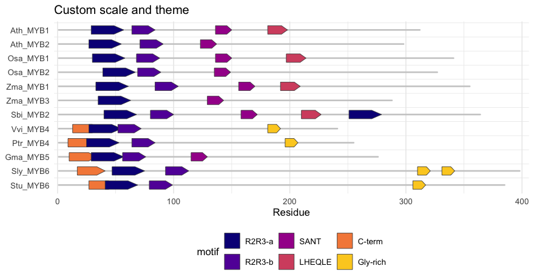

```r
gg_motif_map(res_lab, backbone_colour = "grey80") +
  scale_fill_viridis_d(option = "plasma", end = 0.9) +
  labs(title = "Custom scale and theme", x = "Residue") +
  theme_minimal(base_size = 11) +
  theme(panel.grid.major.y = element_blank(),
        legend.position = "bottom")
```

`geom_motif()` is available if you would rather build the plot from scratch:

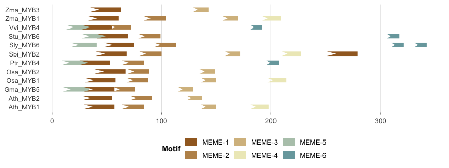

```r
ggplot(res$sites, aes(xmin = start, xmax = stop, y = sequence, fill = motif)) +
  geom_motif(shape = "notch", height = 0.5) +
  scale_fill_motif(palette = "earth") +
  theme_motif()
```

## The Shiny app

`run_memeplotr()` opens an interactive front end: upload `meme.xml` and a Newick file, click the figure into shape, download it as PNG, PDF or SVG - and copy the generated `ggplot2` call from the “R code” tab so the figure can be regenerated in a script later.

```r
run_memeplotr()
```